# FigureYa179AMDAplot

小丫画图出品

2020-5-24

欢迎关注“小丫画图”公众号，回复“小白”，看小视频，实现点鼠标跑代码。

小丫微信: epigenomics E-mail: figureya@126.com

作者：小白仁

小丫编辑校验

# 需求描述

重复文章中ageing-mediated disease alignment score (AMDA score)的算法，并复现原文的Figure3a。

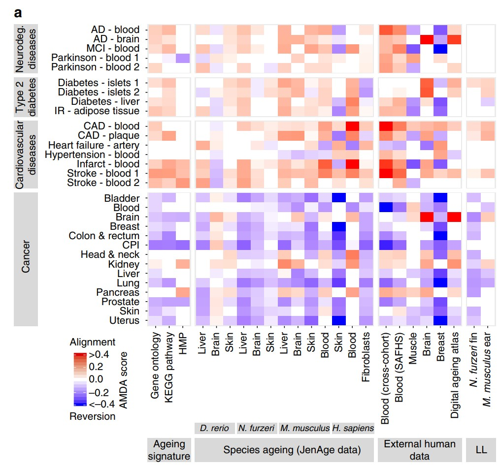

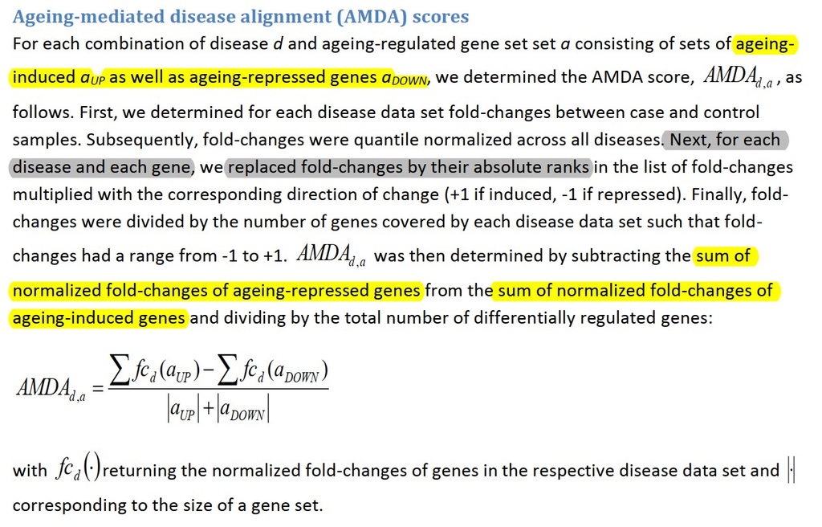

Fig. 3 Association of ageing-associated gene expression changes with ageing diseases and lifespan. a Ageing-mediated disease alignment scores (AMDA scores) for different ageing (x axis) and disease data sets (y axis). Abbreviations: AD Alzheimer’s disease, CAD coronary artery disease, CPI cancer proliferation index, cross-cohort cross-cohort study of blood ageing, HMP human metabolic pathways, IR insulin resistance, LL longitudinal ageing data, MCI mild cognitive impairment; SAFHS, San Antonio Family Heart Study.

出自https://www.nature.com/articles/s41467-017-02395-2

# 应用场景

把自己的数据跟衰老联系起来，肿瘤、非肿瘤领域都可以用起来。具体原理参考下文的“AMDA score算法讲解”。

适用于转录组数据，用文中的公式计算出样本的**AMDA score（量化衰老与疾病相关的指标）**，进行组间对比。

也可以用自己的数据画这种**带有局部二级标签**的热图。

# 环境设置

使用国内镜像安装包

```r
options(BioC_mirror = "https://mirrors.tuna.tsinghua.edu.cn/bioconductor")
options(repos = structure(c(CRAN = "https://mirrors.tuna.tsinghua.edu.cn/CRAN/")))
if (!require("pacman")) install.packages("pacman")
pacman::p_load(svglite, ggplot2, magrittr, patchwork, Rmisc, Cairo, stringr, tidyr,
    tidyfst, data.table, rlist, Hmisc, grid, gtable, gridExtra, ggpubr)
if (!require("DESeq2")) BiocManager::install("DESeq2")
if (!require("S4Vectors")) BiocManager::install("S4Vectors")
if (!require("BiocParallel")) BiocManager::install("BiocParallel")
```

加载R包

```r
library(DESeq2)
library(S4Vectors)
library(BiocParallel)

Sys.setenv(LANGUAGE = "en")  #显示英文报错信息
options(stringsAsFactors = FALSE)  #禁止chr转成factor
```

> 如果你对AMDA score算法不感兴趣，只想画带二级分类标签的热图，就直接跳到“开始画图”。

# AMDA score算法讲解

要明白AMDA score得先看原文中的Figure 3a，其中分为两部分。

- Part-1属于衰老基因集，是作者自己通过不同物种和组织经过年龄分层的多因素ANOVA进行计算所得的。衰老基因集包含了体现衰老信息的差异基因集，里面分为up和down（详见原文Supplementary Data）。衰老基因集是计算AMDA score的基础，但这个无法复现。因为衰老基因集是作者使用包括斑马鱼、非洲青鳉鱼、小鼠和人的各种组织以及纤维细胞系的基因组所计算得出的。所以，Part-1的基因集在Supplementary Data有提供，直接使用即可。
- Part-2是包括cancer、cvd等各种疾病的病人基因组数据，通过不同的分组策略（见原文Supplementary Table 5）后进行差异基因分析（Deseq2)。然后将差异结果里的log2 Foldchange（原文里描述的是Foldchange，其实实际上是log2FC）在进行normalization（详见下文**“计算AMDA score”**），最后得出取值范围为[-1,1]的log2FC值。

**AMDA score公式的分子部分表示某个病种中匹配到某个基因集中up组的差异基因的rank normalization后的log2FC值的和，减去匹配到down组的差异基因的log2FC的和。分母则是这个基因集中up和down组基因的总数量。**

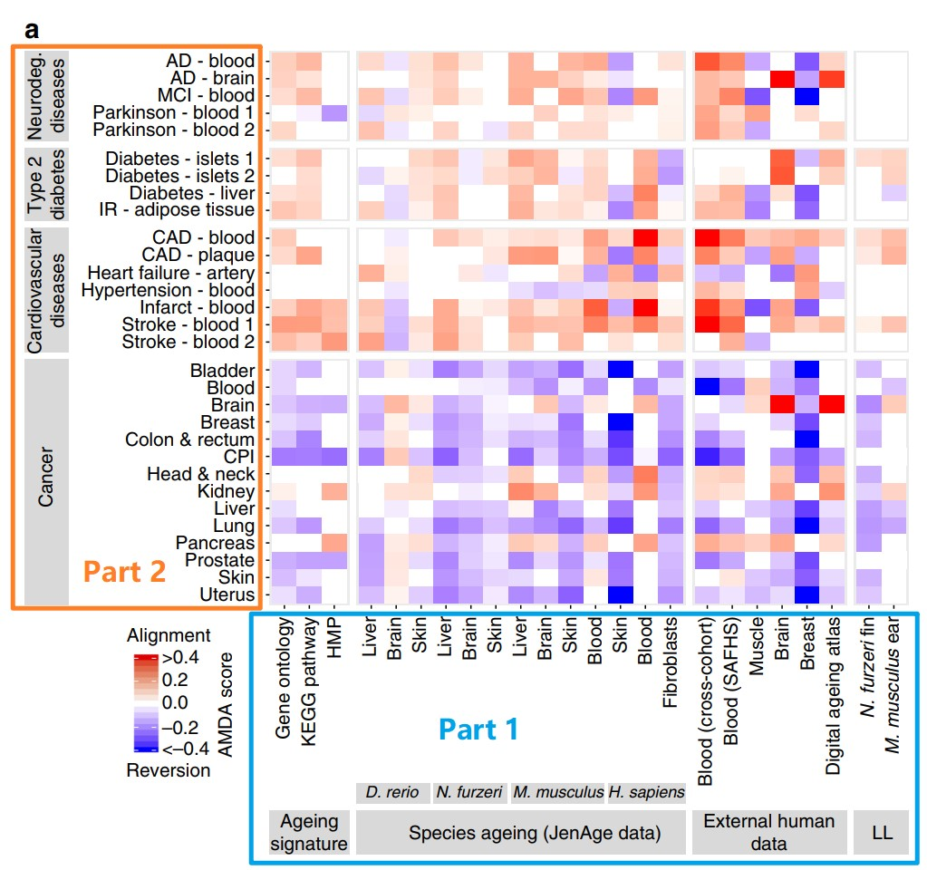

下面以Part-2里的一种疾病为例，展示AMDA score 的计算过程。这里使用**TCGA-BLCA**的转录组数据进行计算（**为什么不用原文中所用的ICGC-BLCA数据，见文末 Q & A**）

# 输入数据预处理

实际应用时，如果已经准备好了基因表达矩阵，可跳过这步，直接进入“差异表达分析”。如果已经做好差异表达分析，就直接进入“输入文件”。

中间文件已上传至微云https://share.weiyun.com/c1ToPq7z

## 清洗TCGA-BLCA数据

这里为了复现原文，因此提取与原文匹配的样本名，用到ICGC-BLCA的转录组数据，但不用里面的raw.count。因ICGC-BLCA数据过大（1.67G），这里不再运行。感兴趣的小伙伴可以自己下载数据放入当前目录内运行。

```r
## 加载ICGC-BLCA的转录组数据
exp <- read.delim("exp_seq.BLCA-US.tsv")  #ICGC-BLCA的转录组数据
## 提取对应的列进行宽数据转换
tmp = exp[, c(5, 8, 10)]
tmp = unique(tmp)
tmp = tmp[!tmp$gene_id == "?", ]
tmp = data.table(tmp)
ans = tmp[, list(raw_read_count = mean(raw_read_count)), by = "submitted_sample_id,gene_id"]
rna <- spread(ans, key = "submitted_sample_id", value = "raw_read_count", fill = NA)
table(str_sub(colnames(rna), 14, 15))
# 与文章中的paired样本数量相符

## 分离对照组
rna = as.data.frame(rna)
control = rna[, str_sub(colnames(rna), 14, 15) == "11"]
row.names(control) = rna[, 1]
## 分离肿瘤组
cases = rna[, (str_sub(colnames(rna), end = 12) %in% str_sub(colnames(control), end = 12)) &
    (str_sub(colnames(rna), 14, 15) == "01")]
cases = cases[, c(-1, -3)]
row.names(cases) = rna[, 1]
table(duplicated(colnames(cases)))
table((str_sub(colnames(cases), end = 12)) == (str_sub(colnames(control), end = 12)))
colnames(cases) = str_sub(colnames(cases), end = 15)
colnames(control) = str_sub(colnames(control), end = 15)
save(cases, file = "BLCA_cases.Rdata")
save(control, file = "BLCA_control.Rdata")
```

为了方便可以直接导入我整理好的与文章中匹配的17对BLCA样本

```r
## 导入用ICGC-BLCA数据整理好的17对配对好的样本
(load(file = "BLCA_cases.Rdata"))
(load(file = "BLCA_control.Rdata"))

## 导入TCGA-BLCA的转录组数据进行样本配对
HTSeq_Counts <- read.delim("HTSeq - Counts.merge.txt")  #TCGA-BLCA的转录组数据
colnames(HTSeq_Counts) %<>% str_replace_all("[/.]", "-")
table(str_sub(colnames(HTSeq_Counts), end = 15) %in% colnames(cases))

# 提取肿瘤样本
cases_tcga = HTSeq_Counts[, str_sub(colnames(HTSeq_Counts), end = 15) %in% colnames(cases)]
cases_tcga$ENSG = HTSeq_Counts[, 1]
cases_tcga <- separate(cases_tcga, ENSG, into = "ENSG", sep = "[.]")
cases_tcga = cases_tcga[str_sub(cases_tcga$ENSG, 1, 4) == "ENSG", ]
cases_tcga = cases_tcga[, c(-12, -19)]  #去掉两个重复样本
write.csv(cases_tcga, "easy_input_case.csv", quote = F)

# 提取control样本
control_tcga = HTSeq_Counts[, str_sub(colnames(HTSeq_Counts), end = 15) %in% colnames(control)]
control_tcga$ENSG = HTSeq_Counts[, 1]
control_tcga <- separate(control_tcga, ENSG, into = "ENSG", sep = "[.]")
control_tcga = control_tcga[str_sub(control_tcga$ENSG, 1, 4) == "ENSG", ]
table(duplicated(control_tcga$ENSG))  #ENSG没有重复
write.csv(control_tcga, "easy_input_control.csv", quote = F)
```

## 差异表达分析

使用DEseq2，与原文一致，对TCGA-BLCA转录组进行差异表达分析。其中基因的row.count数没有进行过滤（比如某基因row.count总和<1的剔除），因为不影响差异结果（已验证）。

```r
# 加载基因表达矩阵 肿瘤组
cases_tcga <- read.csv("easy_input_case.csv", row.names = 1, header = T, check.names = F)
cases_tcga[1:3, 1:3]

# 对照组
control_tcga <- read.csv("easy_input_control.csv", row.names = 1, header = T, check.names = F)
control_tcga[1:3, 1:3]

## 合并肿瘤组和对照组
rownames(cases_tcga) = cases_tcga$ENSG
cases_tcga = cases_tcga[, -ncol(cases_tcga)]
rownames(control_tcga) = control_tcga$ENSG
control_tcga = control_tcga[, -ncol(control_tcga)]
mRNA = cbind(cases_tcga, control_tcga)
type_tissue <- ifelse(as.numeric(substr(colnames(mRNA), 14, 15)) < 10, "tumor", "normal")
table(type_tissue)
type_tissue = relevel(factor(type_tissue), ref = "normal")
mRNA = round(mRNA, digits = 0)  #数据取整，DESeq2需要整数counts
colData <- data.frame(row.names = colnames(mRNA), type = c(type_tissue))  #样本名+类别标签

## 构建dds矩阵
dds <- DESeqDataSetFromMatrix(countData = mRNA, colData = colData, design = ~type)

## 差异分析较久，创建文件方便保存结果
tmp_f = file.path("mRNA.DESeq2-dds.Rdata")
register(SnowParam(6))  #设置多线程
if (!file.exists(tmp_f)) {
    dds <- DESeq(dds, parallel = T)  #进行DESeq差异分析：估计大小因素，估算分散度，gene-wise分散估计，均值-色散关系，最终的分散估计(与原文描述一致)
    save(dds, file = tmp_f)
}  #最耗时（已启用多线程）
```

```r
load("mRNA.DESeq2-dds.Rdata")
res <- results(dds, tidy = F)
DEG = as.data.frame(res)  #转为数据框
head(DEG)
write.csv(DEG, file = "easy_input_DEG.csv")  #保存差异基因
```

## 对log2FC进行标准化，并对比原文提供的经标准化后的log2FC结果

这里使用上面计算的log2Foldchange(原文里描述的是Foldchange，实际上是log2FC(**已证实，详见 Q & A**))进行rank normalization **（原文里是先把所有disease的log2FC进行quantile normalization，再进行单个disease的rank normalization，因为这里只演示一个diseases所以无需进行quantile normalization）**

- STEP1: 先取绝对值进行大小排列，然后经(r-1)/(R-1)变换得出取值范围为[0,1]的log2FC值（**为什么是(r-1)/(R-1)变换而不是r/R变化，详见Q & A**）。
- STEP2: 将取值范围为[0,1]的log2FC值加上log2FC值原有的正负号，使其取值范围变为[-1,1]。

文章提供了一个包含3032个基因的几乎所有diseases（除了Cancer-CPI）的经标准化后的log2FC值（位于Supplementary Data S2）。这个文件与文中Figure3a中AMDA score无关，我们只用它来验证log2FC标准化的结果。

```r
## 导入文章提供的经过标准化后的log2FC值,进行匹配
ori = read.csv("41467_2017_2395_MOESM5_ESM/Supplementary Data S2/DiseaseAlignment-1-4+5/normalizedFoldChanges.csv")
DEG = read.csv("easy_input_DEG.csv")
row.names(DEG) = DEG[, 1]
DEG = DEG[, -1]
all_DEG = DEG[ori$X, ]
all_DEG$val = ori$cancer.bladder
all_DEG$absval = abs(ori$cancer.bladder)
all_DEG$Foldchange = abs(all_DEG$log2FoldChange)  #绝对值log2FC
all_DEG = all_DEG[complete.cases(all_DEG), ]
all_DEG = all_DEG[order(all_DEG$Foldchange), ]  #标准化
all_DEG$rank = c(0:(nrow(all_DEG) - 1))/(nrow(all_DEG) - 1)  #是0开始的
all_DEG$rank = all_DEG$rank * all_DEG$log2FoldChange/abs(all_DEG$log2FoldChange)  #加上正负号
```

画图查看相关性

```r
ggplot(data = all_DEG, aes(x = rank, y = val)) + geom_point(color = "#ffb549") +
    stat_smooth(method = "lm", se = T)
```

[figure not shown]

```r
# 基本吻合
cor.test(all_DEG$rank, all_DEG$val, method = "pearson")
```

```
##
##  Pearson's product-moment correlation
##
## data:  all_DEG$rank and all_DEG$val
## t = 213.85, df = 3029, p-value < 2.2e-16
## alternative hypothesis: true correlation is not equal to 0
## 95 percent confidence interval:
##  0.9661512 0.9705798
## sample estimates:
##       cor
## 0.9684419
```

```r
# 相关系数>0.9
```

# 输入文件

需要用到差异表达分析结果和衰老基因集：

- 衰老基因集，用例文附件提供的多个文本文件，位于当前文件夹里的41467_2017_2395_MOESM5_ESM/Supplementary Data S2/DEGs/1-4+5/
- easy_input_DEG.csv，前面用DESeq2获得的差异表达分析结果。

## 导入原文提供的所有衰老基因集

可以把这套衰老基因集用到自己的paper里，记得引用原文哦～

```r
metabolic <- read.csv("41467_2017_2395_MOESM5_ESM/Supplementary Data S2/DEGs/1-4+5/metabolic.txt",
    sep = "")
breast <- read.csv("41467_2017_2395_MOESM5_ESM/Supplementary Data S2/DEGs/1-4+5/human-breast.txt",
    sep = "")
skin <- read.csv("41467_2017_2395_MOESM5_ESM/Supplementary Data S2/DEGs/1-4+5/human-skin.txt",
    sep = "")
human.daa <- read.csv("41467_2017_2395_MOESM5_ESM/Supplementary Data S2/DEGs/1-4+5/human-daa.txt",
    sep = "")
human.muscle <- read.csv("41467_2017_2395_MOESM5_ESM/Supplementary Data S2/DEGs/1-4+5/human-muscle.txt",
    sep = "")
metabolic <- read.csv("41467_2017_2395_MOESM5_ESM/Supplementary Data S2/DEGs/1-4+5/metabolic.txt",
    sep = "")
SAFHS <- read.csv("41467_2017_2395_MOESM5_ESM/Supplementary Data S2/DEGs/1-4+5/human-blood-SAFHS.txt",
    sep = "")
mouse.blood <- read.csv("41467_2017_2395_MOESM5_ESM/Supplementary Data S2/DEGs/1-4+5/mouse-blood.txt",
    sep = "")
go <- read.csv("41467_2017_2395_MOESM5_ESM/Supplementary Data S2/DEGs/1-4+5/go.txt",
    sep = "")
danio.brain <- read.csv("41467_2017_2395_MOESM5_ESM/Supplementary Data S2/DEGs/1-4+5/danio-brain.txt",
    sep = "")
data.list = list.files("41467_2017_2395_MOESM5_ESM/Supplementary Data S2/DEGs/1-4+5/",
    pattern = "*.txt")
all = list()
for (i in 1:length(data.list)) {
    x = read.csv(paste0("41467_2017_2395_MOESM5_ESM/Supplementary Data S2/DEGs/1-4+5/",
        data.list[i]), sep = "")
    up = x[1:which(x$Up. == "Down:") - 1, 1]
    if (isEmpty(which(x$Up. == "Other:"))) {
        down = x[which(x$Up. == "Down:") + 1:nrow(x), 1]
    } else {
        down = x[((which(x$Up. == "Down:") + 1):(which(x$Up. == "Other:") - 1)),
            1]
        all[[i]] = list(data.list[i], up, down)
    }
}
```

## 加载差异表达分析结果

```r
DEG <- read.csv("easy_input_DEG.csv", row.names = 1)
head(DEG)
```

```
##                    baseMean log2FoldChange     lfcSE       stat       pvalue
## ENSG00000000003 4771.417908      0.2698784 0.4055147  0.6655206 5.057176e-01
## ENSG00000000005    6.935404     -2.7774460 0.5353836 -5.1877678 2.128297e-07
## ENSG00000000419 1821.167982      0.4293871 0.1279488  3.3559307 7.909840e-04
## ENSG00000000457  738.174395      0.3887471 0.1723461  2.2556186 2.409453e-02
## ENSG00000000460  445.045490      1.7154524 0.1916625  8.9503828 3.542516e-19
## ENSG00000000938  457.550568     -0.3392406 0.3062881 -1.1075867 2.680404e-01
##                         padj
## ENSG00000000003 6.502501e-01
## ENSG00000000005 3.872408e-06
## ENSG00000000419 4.293663e-03
## ENSG00000000457 6.924242e-02
## ENSG00000000460 1.180827e-16
## ENSG00000000938 4.189136e-01
```

# 计算AMDA score和p值

使用标准化后的log2FC值计算AMDA.score并计算p值。计算结果与原文的AMDA score基本吻合，偏差来源分析见Q & A。

```r
test = data.frame()
for (i in 1:length(data.list)) {
    n = unlist(all[[i]][1])  #name
    x = unlist(all[[i]][2])  #up
    y = unlist(all[[i]][3])  #down
    xx = table(x %in% row.names(DEG))
    yy = table(y %in% row.names(DEG))
    all_DEG = DEG[c(x, y), ]  #合并up和down基因集
    all_DEG = all_DEG[complete.cases(all_DEG), ]
    all_DEG$Foldchange = abs(all_DEG$log2FoldChange)  #绝对值log2FC
    all_DEG = all_DEG[order(all_DEG$Foldchange), ]  #标准化
    all_DEG$rank = c(0:(nrow(all_DEG) - 1))/(nrow(all_DEG) - 1)  #0开始
    all_DEG$rank = all_DEG$rank * all_DEG$log2FoldChange/abs(all_DEG$log2FoldChange)
    res = (sum(na.omit(all_DEG[x, "rank"])) - sum(na.omit(all_DEG[y, "rank"])))/length(c(x,
        y))
    a = wilcox.test(na.omit(all_DEG[x, "rank"]), na.omit(all_DEG[y, "rank"]), paired = FALSE,
        exact = F, correct = TRUE, conf.int = FALSE, conf.level = 0.95)
    # Wilcoxon rank-sum test of normalized foldchanges of genes from a disease data
    # sets between ageing-repressed and ageing-induced genes(原文)
    test = rbind(test, cbind(n, res, a[["p.value"]], xx["TRUE"]/sum(xx), yy["TRUE"]/sum(yy)))
}
rownames(test) = c(1:nrow(test))
colnames(test) = c("fact", "AMDA.score", "AMDA.padj", "up%", "down%")
test$AMDA.score %<>% as.numeric()
test$AMDA.padj %<>% as.numeric()

# 把AMDA score保存到文件
write.csv(test, "AMDAscore_output.csv", row.names = F, quote = F)
```

## 导入原文的AMDA score进行比较

```r
AMDA <- read.csv("41467_2017_2395_MOESM5_ESM/Supplementary Data S2/DiseaseAlignment-1-4+5/AMDA-dirs.csv")
test$oriAMDA = AMDA$cancer.bladder
ggplot(test, aes(x = AMDA.score, y = oriAMDA)) + geom_point(color = "#ffb549") +
    stat_smooth(method = "lm", se = T)
```

[figure not shown]

```r
cor.test(test$AMDA.score, test$oriAMDA, method = "pearson")
```

```
##
##  Pearson's product-moment correlation
##
## data:  test$AMDA.score and test$oriAMDA
## t = 17.831, df = 22, p-value = 1.447e-14
## alternative hypothesis: true correlation is not equal to 0
## 95 percent confidence interval:
##  0.9242905 0.9858797
## sample estimates:
##       cor
## 0.9670988
```

这里算出的AMDA score跟原文的相关系数为0.967。

# 开始画图

以上BLCA的AMDA score对应图中的一行。实际应用时，如果有多组对比，可以像例文那样用热图展示；如果只有一组对比，可以换成柱形图或lollipop等方式展示。

这里复现文中的Figure 3a的带局部二级标签的heatmap

## 输入文件预处理

直接使用**文章的Supplementary Data S2的数据**复现Figure 3a，对照图来理解语句的含义。

```r
AMDA <- read.csv("41467_2017_2395_MOESM5_ESM/Supplementary Data S2/DiseaseAlignment-1-4+5/AMDA-dirs.csv")  #导入文中数据进行比对
head(AMDA)
```

```
##                              X cancer.uterus cancer.skin cancer.prostate
## 1              danio-brain.txt    0.01728382  0.03472878      0.03763167
## 2              danio-liver.txt   -0.08287370 -0.11766284     -0.12025732
## 3               danio-skin.txt   -0.06194158 -0.02460060     -0.04657566
## 4              fibroblasts.txt   -0.13545996 -0.09578552     -0.08867650
## 5                       go.txt   -0.03940480 -0.08223566     -0.10242794
## 6 human-blood-cross-cohort.txt   -0.07532004 -0.01495511     -0.17377228
##    cancer.lung cancer.liver cancer.kidney cancer.Head...Neck
## 1 -0.003709904 -0.022279379    0.04544351        0.005197934
## 2 -0.066264145  0.004576673   -0.02069866       -0.023032728
## 3 -0.044282924 -0.008663789    0.04804014        0.060324994
## 4 -0.168379605 -0.070908584   -0.08169629       -0.097697580
## 5 -0.073560544 -0.044379639    0.02207250        0.005773793
## 6 -0.198427960 -0.063385606    0.05575890        0.061894315
##   cancer.Colon...Rectum cancer.breast cancer.bladder cancer.blood cancer.brain
```

[output cut: 41 more lines]

```r
AMDA$X %<>% str_sub(end = -5)
heat <- pivot_longer(AMDA, -X, names_to = "diseases", values_to = "AMDA.score")
heat <- as.data.frame(heat)
Cancer <- heat$diseases[1:14]
Cardiovasculardiseases <- heat$diseases[15:21]
Neurodeg.diseases <- heat$diseases[22:26]
Type2diabetes <- heat$diseases[27:30]
Ageingsignature <- c("metabolic", "kegg", "go")
Speciesageing <- c("danio-liver", "danio-brain", "danio-skin", "notho-liver", "notho-brain",
    "notho-skin", "mouse-liver", "mouse-brain", "mouse-skin", "mouse-blood", "human-skin",
    "human-blood", "fibroblasts")
Externalhumandata = c("human-blood-cross-cohort", "human-blood-SAFHS", "human-muscle",
    "human-brain", "human-breast", "human-daa")
LL = c("notho-longitudinal", "mouse-longitudinal")

heat$xx <- ifelse(heat$X %in% Ageingsignature, "Ageingsignature", ifelse(heat$X %in%
    Speciesageing, "Speciesageing", ifelse(heat$X %in% Externalhumandata, "Externalhumandata",
    "LL")))
heat$yy <- ifelse(heat$diseases %in% Cancer, "Cancer", ifelse(heat$diseases %in%
    Cardiovasculardiseases, "Cardiovasculardiseases", ifelse(heat$diseases %in% Type2diabetes,
    "Type2diabetes", "Neurodeg.diseases")))

heat$xx %<>% factor(levels = c("Ageingsignature", "Speciesageing", "Externalhumandata",
    "LL"), ordered = T)
heat$yy %<>% factor(levels = c("Neurodeg.diseases", "Type2diabetes", "Cardiovasculardiseases",
    "Cancer"), ordered = T)
heat$X %<>% factor(levels = c("go", "kegg", "metabolic", "danio-liver", "danio-brain",
    "danio-skin", "notho-liver", "notho-brain", "notho-skin", "mouse-liver", "mouse-brain",
    "mouse-skin", "mouse-blood", "human-skin", "human-blood", "fibroblasts", "human-blood-cross-cohort",
    "human-blood-SAFHS", "human-muscle", "human-brain", "human-breast", "human-daa",
    "notho-longitudinal", "mouse-longitudinal"), ordered = T, labels = c("Gene ontology",
    "KEGG pathway", "HMP", "Liver", "Brain", "Skin", " Liver", " Brain", " Skin",
    "  Liver", "  Brain", "  Skin", "Blood", "   Skin", " Blood", "Fibroblasts",
    "   Blood (cross-cohort)", "Blood (SAFHS)", "Muscle", "   Brain", "Breast", "Digital ageing atlas",
    "N. furzeri fin", "M. musculus ear"))
heat$diseases %<>% factor(levels = c(sort(names(table(heat[heat$yy == "Cancer", "diseases"])),
    decreasing = T), sort(names(table(heat[heat$yy == "Cardiovasculardiseases", "diseases"])),
    decreasing = T), sort(names(table(heat[heat$yy == "Type2diabetes", "diseases"])),
    decreasing = T), sort(names(table(heat[heat$yy == "Neurodeg.diseases", "diseases"])),
    decreasing = T)), ordered = T, labels = c("Uterus", "Skin", "Prostate", "Pancreas",
    "Lung", "Liver", "
                                              Kidney", "Head & neck",
    "CPI", "Colon & rectum", "Breast", "Brain", "Blood", "Bladder", "Stroke - blood 2",
    "Stroke - blood 1", "Infarct - blood", "Hypertension - blood", "Heart failure - artery",
    "CAD - plaque", "CAD - blood", "IR - adipose tissue", "Diabetes - liver", "Diabetes - islets 2",
    "Diabetes - islets 1", "Parkinson - blood 2", "Parkinson - blood 1", "MCI - blood",
    "AD - brain", "AD - blood"))

# x轴二级分类标签
tableGL <- data.frame(group = c(1:13), labels = rep(NA, 13), subgroup = c(rep("D. rerio",
    3), rep("N. furzeri", 3), rep("M. musculus", 4), rep("H. sapiens", 3)))
tableGL$subgroup %<>% factor(levels = c("D. rerio", "N. furzeri", "M. musculus",
    "H. sapiens"))

labx <- c(Ageingsignature = paste("Ageing", "\n", "signature"), Speciesageing = "Species ageing (JenAge data)",
    Externalhumandata = paste("External human", "\n", "data"), LL = "LL")

# y轴二级分类标签
laby <- c(Cardiovasculardiseases = paste("Cardiovascular", "\n", "diseases"), Type2diabetes = paste("Type2",
    "\n", "diabetes"), Neurodeg.diseases = paste("Neurodeg.", "\n", "diseases"),
    Cancer = "Cancer")
```

## 画主图

```r
s <- 10  #统一字体大小
p_cor.order <- ggplot(heat, aes(X, diseases)) + geom_tile(aes(fill = round(AMDA.score,
    2))) + theme(axis.text.y = element_text(size = s, face = "bold", margin = margin(r = 5)),
    axis.title = element_blank(), axis.text.x = element_text(angle = 90, hjust = 1,
        vjust = 0.3, face = "bold", size = s, margin = margin(t = 5)), legend.key.height = unit(0.2,
        "inch"), legend.key.width = unit(0.25, "inch"), legend.text = element_text(size = s -
        0.2), legend.background = element_blank(), legend.title = element_text(angle = 90,
        vjust = -0.5, hjust = 0.5), plot.margin = unit(c(1, 2, 1, 1), "lines")) +
    scale_fill_gradientn(limits = c(-0.42, 0.42), na.value = "#ff0000", breaks = c(-0.4,
        -0.2, 0, 0.2, 0.4), labels = c("<-0.4", "-0.2", "0", "0.2", ">0.4"), values = c(0,
        0.1, 0.5, 0.9, 1), colours = c("#0000ff", "#0000ff", "#ffffff", "#ff351c",
        "#ff0000")) + guides(fill = guide_colourbar(title = "AMDA score", title.position = "right"))

# 加二级分类标签
p1 <- p_cor.order + facet_grid(yy ~ xx, scales = "free", space = "free", switch = "both",
    labeller = labeller(xx = labx, yy = laby)) + theme(strip.text = element_text(size = 11,
    hjust = 0.5), strip.placement = "outside")

# 保存到文件
pdf("AMDAplot_pri.pdf", width = 11, height = 9)
p1
dev.off()
```

[figure not shown]

> 输出的pdf文件是矢量图，可以用Illustrator等软件打开，手动编辑。

> 追求全自动，用代码画出物种拉丁名那行，下面会用到grid。如果理解有困难，可以到这里结束。

## 画局部二级标签

```r
p2 <- ggplot() + geom_text(data = tableGL, aes(label = labels, x = group), y = 0.5,
    size = 0) + theme_pubr() + theme(axis.line = element_blank(), axis.ticks = element_blank(),
    axis.text = element_blank(), axis.title = element_blank(), aspect.ratio = 1e-04/10000,
    plot.margin = unit(c(6, 0.1, 0, 0.1), "lines")) + facet_grid(~subgroup, scales = "free_x",
    space = "free_x", switch = "x") + theme(strip.text = element_text(size = 10,
    hjust = 0.5, face = "italic"), strip.background = element_rect(fill = "#d9d9d9",
    color = "#d9d9d9"))
# ——————转为grid对象
pg1 = ggplotGrob(p1)
pg2 = ggplotGrob(p2)
# ——————提取亚标签、合并
pg2 <- gtable_filter(pg2, "(background|strip-b-[1234])", trim = T, invert = F)
pgn <- gtable_add_grob(pg1, pg2, t = 14, l = 9, r = 9, z = 2)
```

## 提取legend、添加上下文字、合并图层

```r
pgn2 <- gtable_filter(pgn, "(guide-box)", trim = T, invert = F)
pgn2 <- pgn2[["grobs"]][[1]][["grobs"]][[1]]  #去壳
pgn <- gtable_filter(pgn, "(tag|guide-box|caption)", trim = T, invert = T)  #删除原有标签

Alignment <- textGrob("Alignment", gp = gpar(fontsize = 10))
Reversion <- textGrob("Reversion", gp = gpar(fontsize = 10))
padding <- unit(0.5, "line")

# 根据布局调整pos
gtable_show_layout(pgn2)
```

[figure not shown]

```r
pgn3 <- gtable_add_rows(pgn2, heights = grobHeight(Alignment) + padding, pos = 0)
pgn3 <- gtable_add_rows(pgn3, heights = grobHeight(Reversion) + padding, pos = 6)
pgn3 <- gtable_add_grob(pgn3, list(Alignment), t = 1, l = 1, r = ncol(pgn3))
pgn3 <- gtable_add_grob(pgn3, list(Reversion), t = 6, l = 1, r = ncol(pgn3))
pgn <- gtable_add_grob(pgn, pgn3, t = 14, l = 6, r = 6, z = 13)  #合并，固定位置
```

## 输出图片

[figure not shown]

# Q & A

## 1. 为什么确定原文用的log2FC标准化是(r-1)/(R-1)变换而不是r/R变换? 为什么说原文里描述的是Foldchange，实际上是log2FC？

答：我们可以打开原文提供的包含3032个基因的经标准化后的FC值。

```r
ori <- read.csv("41467_2017_2395_MOESM5_ESM/Supplementary Data S2/DiseaseAlignment-1-4+5/normalizedFoldChanges.csv")
```

我们会发现，每一列是独立的disease，行是3032个基因，每一列按大小排列后值都是一样的

```r
as.numeric(unlist(lapply(ori[, -1], max)))  #最大值
```

```
##  [1] 1 1 1 1 1 1 1 1 1 1 1 1 1 1 1 1 1 1 1 1 1 1 1 1 1 1 1 1 1 1 1 1 1 1 1 1 1 1
## [39] 1 1 1
```

```r
as.numeric(unlist(lapply(ori[, -1], min)))  #最小值
```

```
##  [1] -0.9996701 -0.9996701 -0.9996701 -0.9996701 -0.9996701 -0.9996701
##  [7] -0.9996701 -0.9996701 -0.9996701 -0.9996701 -0.9996701 -0.9996701
## [13] -0.9996701 -0.9996701 -0.9996701 -0.9996701 -0.9996701 -0.9996701
## [19] -0.9996701 -0.9996701 -0.9996701 -0.9996701 -0.9996701 -0.9996701
## [25] -0.9996701 -0.9996701 -0.9996701 -0.9996701 -0.9996701 -0.9996701
## [31] -0.9996701 -0.9996701 -0.9996701 -0.9996701 -0.9996701 -0.9996701
## [37] -0.9996701 -0.9996701 -0.9996701 -0.9996701 -0.9996701
```

```r
as.numeric(unlist(lapply(ori[, -1], median)))  #中位数
```

```
##  [1] 0.03497196 0.03497196 0.03497196 0.03497196 0.03497196 0.03497196
##  [7] 0.03497196 0.03497196 0.03497196 0.03497196 0.03497196 0.03497196
## [13] 0.03497196 0.03497196 0.03497196 0.03497196 0.03497196 0.03497196
## [19] 0.03497196 0.03497196 0.03497196 0.03497196 0.03497196 0.03497196
## [25] 0.03497196 0.03497196 0.03497196 0.03497196 0.03497196 0.03497196
## [31] 0.03497196 0.03497196 0.03497196 0.03497196 0.03497196 0.03497196
## [37] 0.03497196 0.03497196 0.03497196 0.03497196 0.03497196
```

```r
lapply(ori[, 2:5], function(x) {
    table(x > 0)
})  #这里可以看到每个样本正负的数量都是一样的，这是quantile normalization的证据（为了减少篇幅只取前几列）
```

```
## $cancer.uterus
##
## FALSE  TRUE
##  1464  1568
##
## $cancer.skin
##
## FALSE  TRUE
##  1464  1568
##
## $cancer.prostate
##
## FALSE  TRUE
##  1464  1568
##
## $cancer.lung
##
## FALSE  TRUE
##  1464  1568
```

这里证实了作者是先对所有disease进行quantile normalization，也**说明了作者不是用foldchange**。如果使用foldchange，所有负值将变成最小的正值，当进行绝对值的rank normalization后加上原有的正负号会出现**最显著的负的log2FC会变成最不显著的负的log2FC**，这个可以自己去试一下。

接下来取某一列乘以3032，还原r/R变换

```r
head(sort(abs(ori[, 2]) * 3032, decreasing = F))
```

```
## [1] 0.00000 1.00033 2.00066 3.00099 4.00132 5.00165
```

这里发现*3032后最小值是0，而且其他数都不是整数，这与文章描述的不一致（原文：replaced fold-changes by their absolute ranks in the list of fold-changes）

```r
head(sort(abs(ori[, 2]) * 3031, decreasing = F))
```

```
## [1] 0 1 2 3 4 5
```

```r
# 换成*3031，结果都是整数完全符合(r-1)/(R-1)变换
```

## 2. 为什么不用原文中所用的ICGC-BLCA数据而用TCGA的？

答：ICGC-BLCA转录组数据中基因名是gene id和gene alias（基因别名）构成，这导致了很严重的问题。在基因ID转换的过程中（不管是用org.Hs.eg.db还是自己读取GTF进行匹配），会出现gene id与ensembl id多对多的情况。更严重的是，因为ICGC是gene id和gene alias混用，会导致某些gene alias匹配到其对应的gene id的ensembl id，也会出现一个ensembl id匹配到多个gene id和gene alias，导致多对多。这种结果会使得我们无法判断作者提供的normalizedFoldChanges.csv是属于ICGC里面的哪想基因（文中作者描述是使用Bimart进行转换，但Bimart同样也会遇到多对多转换，所以面临着随机性，可能某些gene id变成与其ensembl id下gene alias同名的gene id的ensembl id**（这也是复现这个图才发现的一个ID转换的坑！）**）。 因此，这次直接用TCGA-BLCA的数据，里面是ensembl id，直接使用即可，不过这也导致了下面的问题：计算结果偏差，**经对比发现，ICGC转录组的raw.count和TCGA的raw.count完全不一致（相同sample下）**。

## 3. 计算结果与原文的AMDA score的偏差是什么导致的？

答：除了上面说的用了TCGA导致的偏差外，还有一个文章本身的原因。 通过读取文章Supplementary Data S2中所有作者自己计算出的衰老基因集发现，大多数衰老基因集的up和down个数与文章中Supplementary Table 3列出的个数不一致（记得只有metabolism是一致的）。这可能是作者在处理数据时出现的差错。